# Pemodelan SARIMA

David Fauzan Akmal

2024-11-03

## Packages

```r
library(readxl)
library(tidyverse)
library(forecast)
library(TSA)
library(aTSA)
library(lmtest)
```

## Impor Data

```r
angkutan <- read_excel("C://Users/USER/Downloads/dataangkutan.xlsx")
head(angkutan)
```

```
## # A tibble: 6 × 2
##   Periode             `Jumlah Barang Angkutan`
##   <dttm>                                 <dbl>
## 1 2008-01-01 00:00:00                      350
## 2 2008-02-01 00:00:00                      297
## 3 2008-03-01 00:00:00                      347
## 4 2008-04-01 00:00:00                      341
## 5 2008-05-01 00:00:00                      379
## 6 2008-06-01 00:00:00                      357
```

## Mengubah data agar terbaca sebagai data deret waktu

```r
angkutan.ts <- ts(angkutan$`Jumlah Barang Angkutan`, frequency = 12) #Karena data bulanan
summary(angkutan.ts)
```

```
##    Min. 1st Qu.  Median    Mean 3rd Qu.    Max.
##   191.0   381.8   767.0   740.9   991.0  1447.0
```

```r
class(angkutan.ts)
```

```
## [1] "ts"
```

## Eksplorasi Data

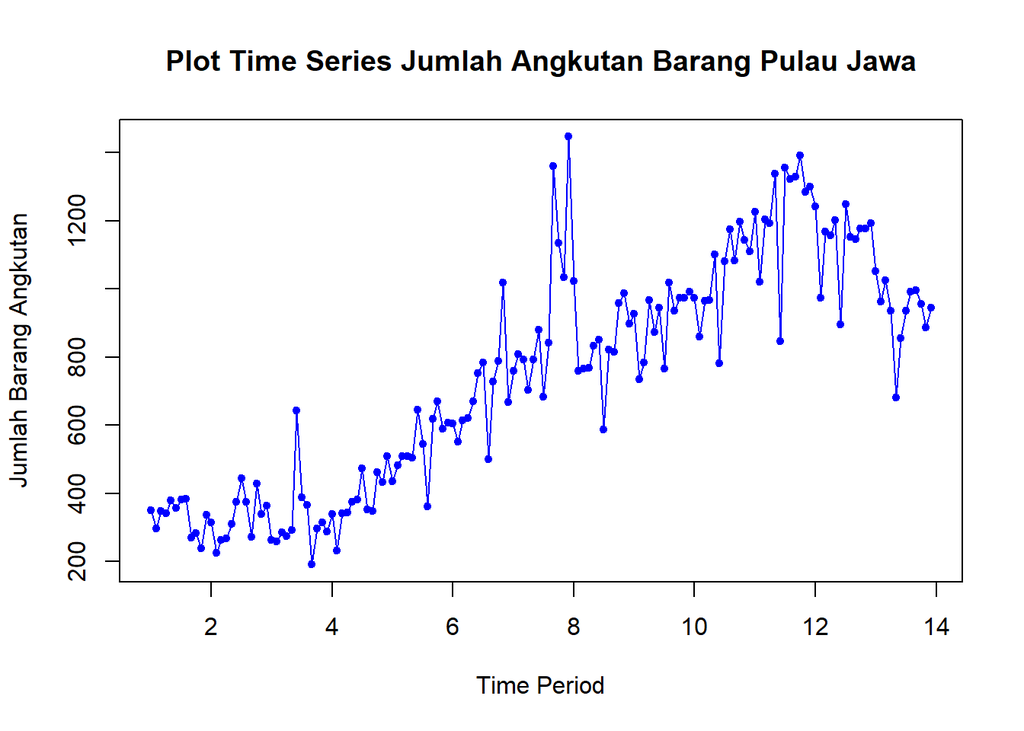

```r
ts.plot(angkutan.ts, type="l", xlab = "Time Period", ylab="Jumlah Barang Angkutan", col="blue")
title(main = "Plot Time Series Jumlah Angkutan Barang Pulau Jawa", cex.sub = 0.8)
points(angkutan.ts, pch = 20, col = "blue")
```

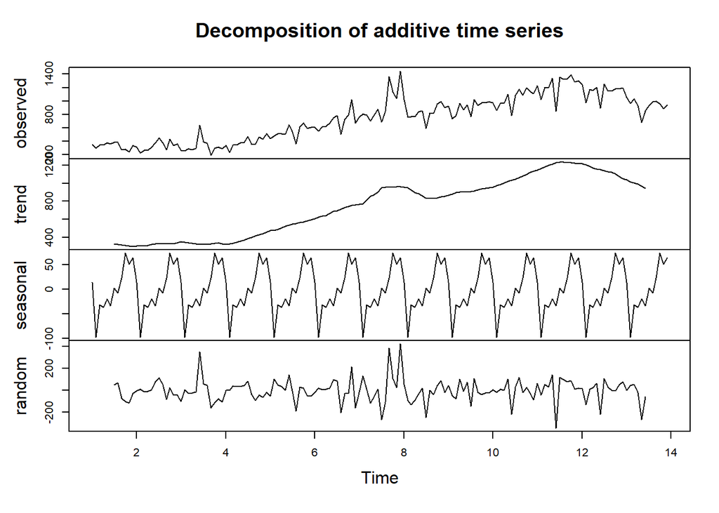

```r
dec.angkutan <- decompose(angkutan.ts)
plot(dec.angkutan)
```

Dari eksplorasi tersebut, terlihat adanya kecenderungan data memiliki tren naik dan perilaku berulang kecenderungan musiman dalam deret tersebut.

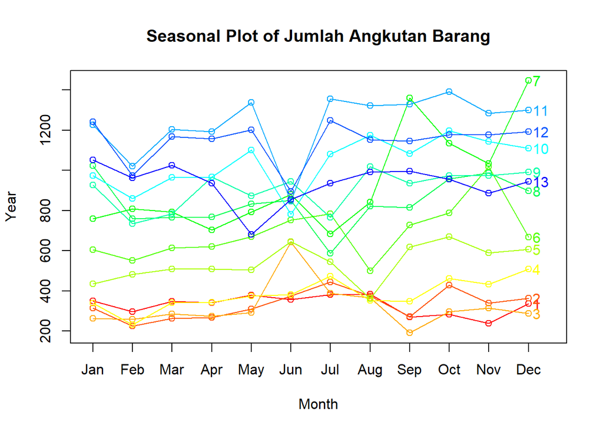

```r
seasonplot(angkutan.ts,12,main="Seasonal Plot of Jumlah Angkutan Barang", ylab="Year",
           year.labels = TRUE, col=rainbow(18))
```

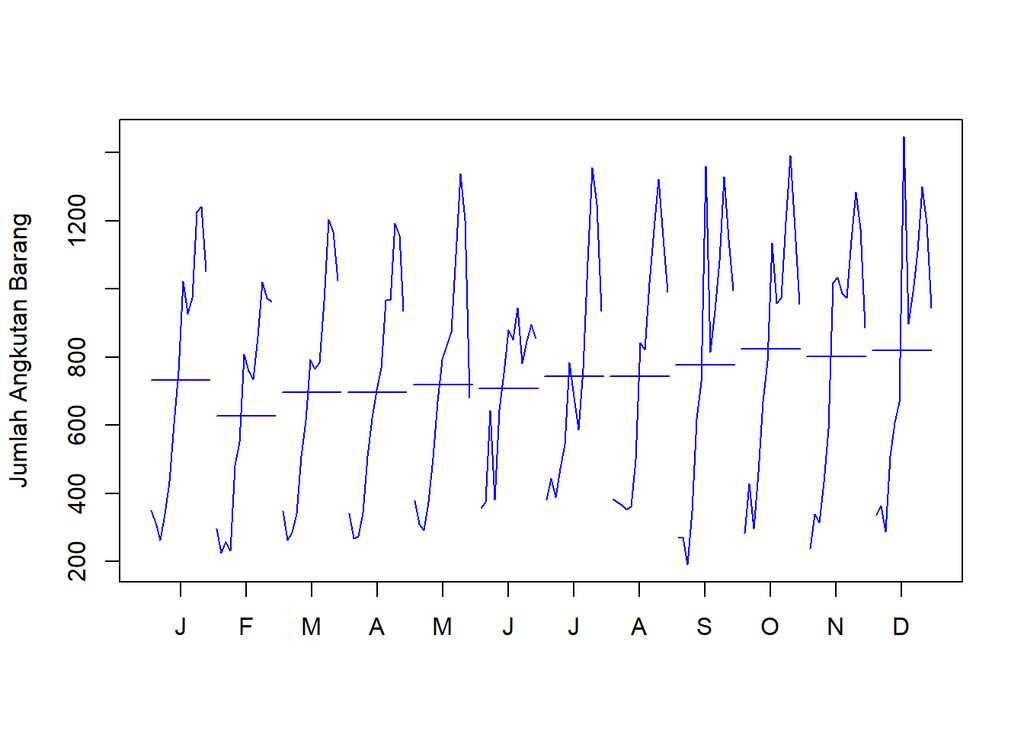

```r
monthplot(angkutan.ts,ylab="Jumlah Angkutan Barang", col="blue")
```

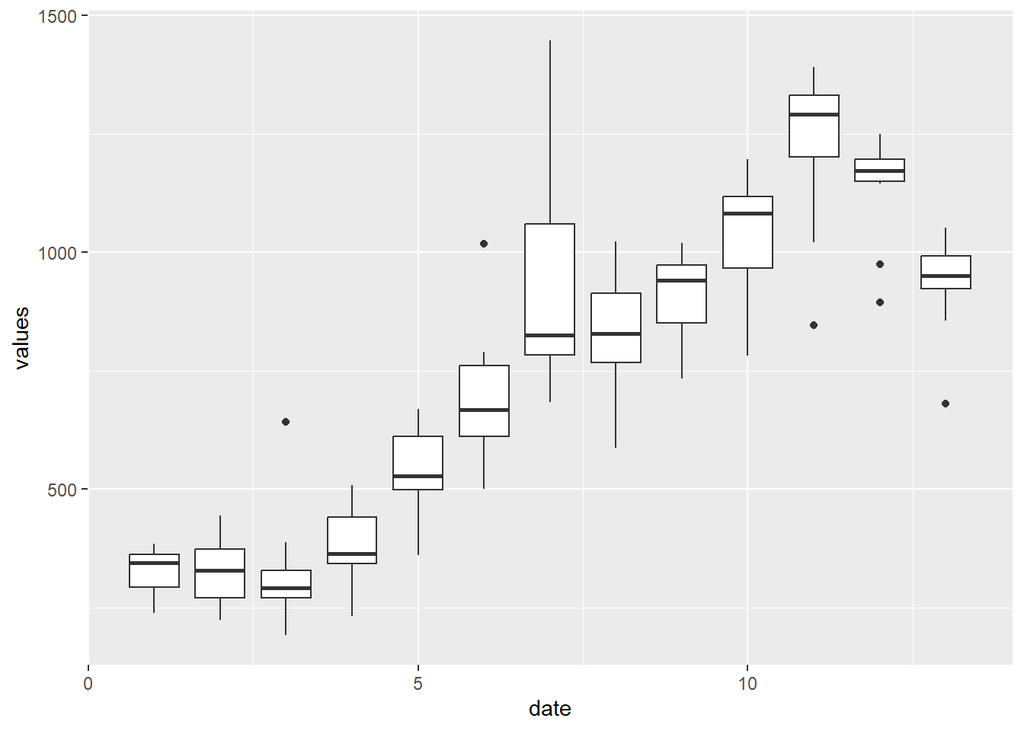

```r
frame<-data.frame(values=as.matrix(angkutan.ts), date=lubridate::year(zoo::as.Date(angkutan.ts)))

library(ggplot2)
ggplot(frame,aes(y=values,x=date,group=date))+
  geom_boxplot()
```

Berdasarkan hasil plot di atas dapat terlihat bahwa data memiliki pola yang hampir sama dari tahun ke tahun sehingga dapat disimpulkan bahwa periode musimannya adalah 12. Selain itu, apabila dilihat dari boxplot, terlihat bahwa data cenderung heterogen dari tahun ke tahun karena panjang box nya cukup berbeda-beda. Untuk memastikan bahwa data homogen atau tidak akan dilakukan uji homogenitas dengan fligner.test.

## Uji Homogenitas

```r
library(car)
fligner.test(values ~ date, data=frame)
```

```
##
##  Fligner-Killeen test of homogeneity of variances
##
## data:  values by date
## Fligner-Killeen:med chi-squared = 16.374, df = 12, p-value = 0.1747
```

Berdasarkan hasil uji Fligner-Killeen dengan menggunakan taraf signifikansi α=5% didapatkan p-value sebesar 0.1747. p−value=0.1747 > α=0.05 sehingga tak tolak H0 atau dengan kata lain ragam data sudah homogen.

## Pembagian Data

Pembagian data tidak dapat dilakukan tepat 80% dan 20% karena menyebabkan perubahan arah kurva pada amatan tersebut. Jadi dengan melihat pola data, data dibagi dengan mengambil data pada amatan 1-128 sebagai data latih dan amatan ke 129-156 sebagai data uji.

```r
train.ts <- subset(angkutan.ts, start=1, end=128)
test.ts <- subset(angkutan.ts, start=129, end=156)
```

# Plot Data Latih

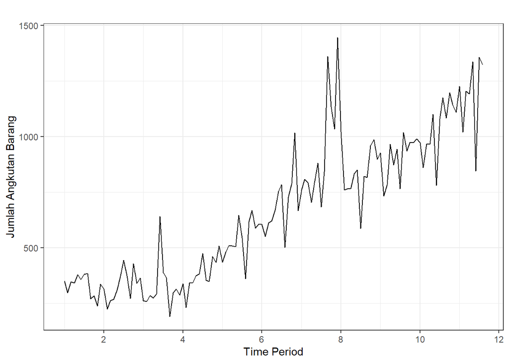

```r
autoplot(train.ts) + theme_bw() + xlab("Time Period") + ylab("Jumlah Angkutan Barang")
```

# Plot Data Uji

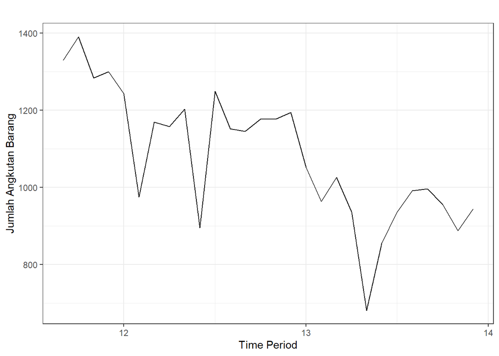

```r
autoplot(test.ts) + theme_bw() + xlab("Time Period") + ylab("Jumlah Angkutan Barang")
```

# Kestasioneran Data

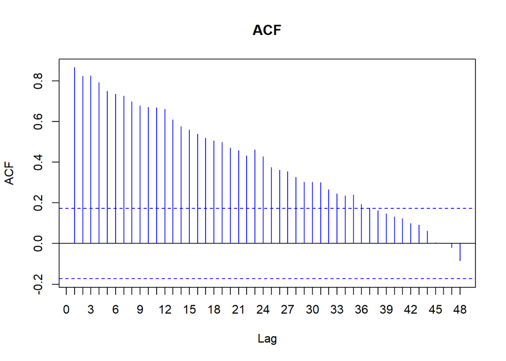

```r
acf0 <- acf(train.ts,main="ACF",lag.max=48,xaxt="n", col="blue")
axis(1, at=0:48/12, labels=0:48)
```

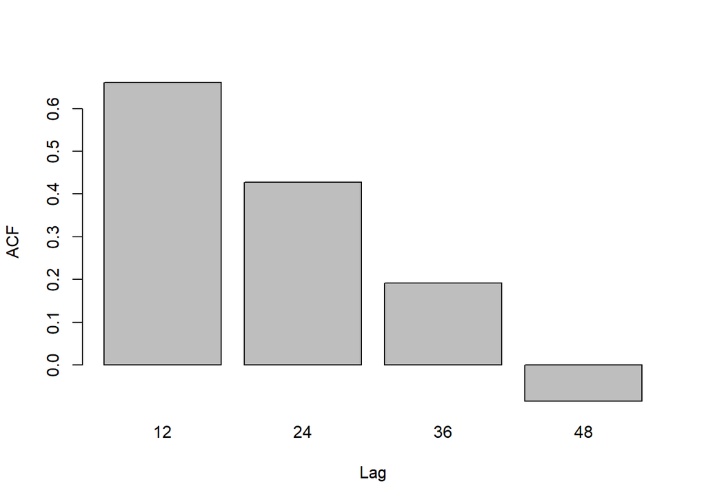

```r
acf0$lag <- acf0$lag * 12
acf0.1 <- as.data.frame(cbind(acf0$acf,acf0$lag))
acf0.2 <- acf0.1[which(acf0.1$V2%%12==0),]
barplot(height = acf0.2$V1,
names.arg=acf0.2$V2, ylab="ACF", xlab="Lag")
```

```r
tseries::adf.test(train.ts)
```

```
##
##  Augmented Dickey-Fuller Test
##
## data:  train.ts
## Dickey-Fuller = -3.5024, Lag order = 5, p-value = 0.04494
## alternative hypothesis: stationary
```

H0: Data tidak stasioner dalam rataan H1: Data stasioner dalam rataan

Berdasarkan uji ADF tersebut, didapat p-value sebesar 0.04494 yang lebih kecil dari taraf nyata 5% sehingga tolak H0 dan menandakan bahwa data stasioner dalam rataan. Hal ini berbeda dengan hasil eksplorasi menggunakan plot ACF. Dari plot time series terdapat tren naik sehingga tetap perlu differencing.

# Pembedaan

Dilakukan pembedaan karena plot time series terdapat tren naik. Pembedaan dilakukan dengan ordo 1.

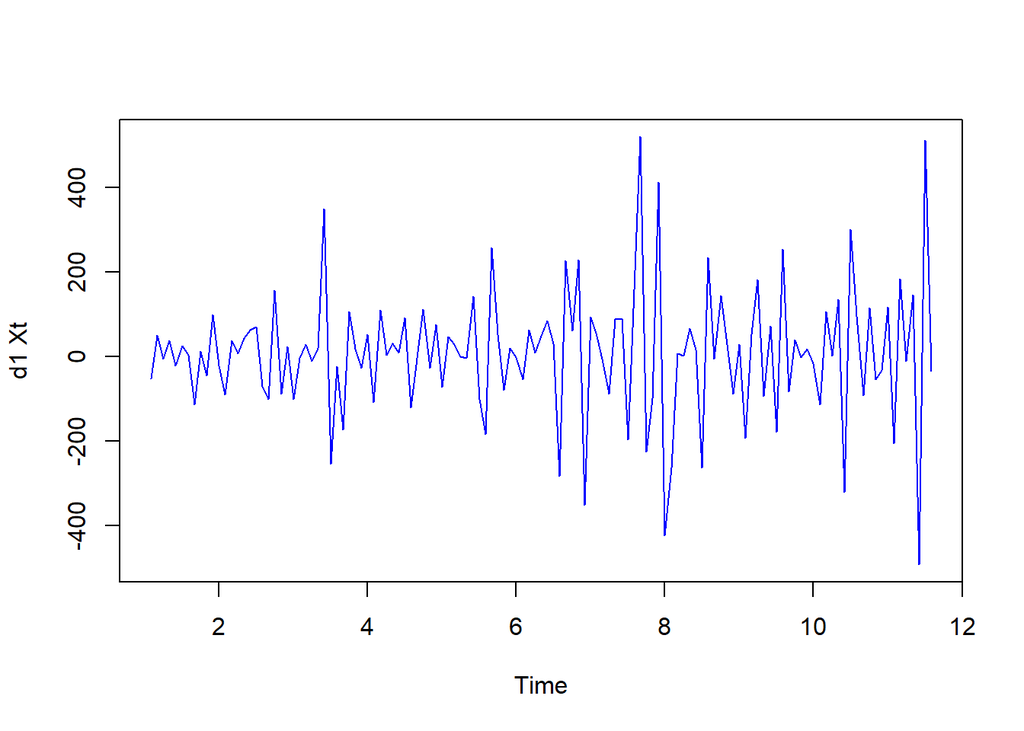

```r
d1 <- diff(train.ts)
ts.plot(d1, type="l", ylab="d1 Xt", col="blue")
```

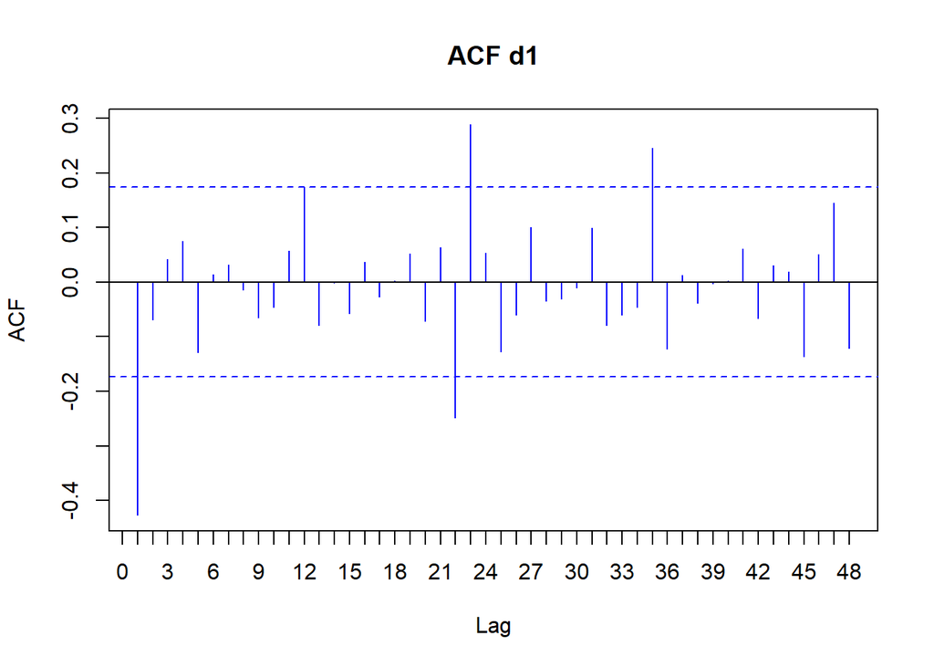

```r
acf1 <- acf(d1,lag.max=48,xaxt="n", main="ACF d1", col="blue")
axis(1, at=0:48/12, labels=0:48)
```

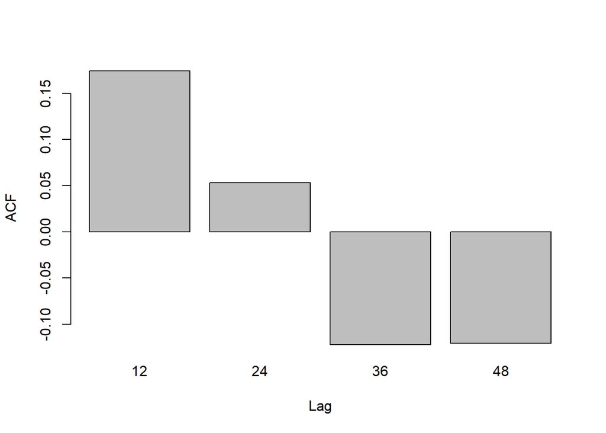

```r
acf2 <- acf1$lag <- acf1$lag * 12
acf1.1 <- as.data.frame(cbind(acf1$acf,acf1$lag))
acf1.2 <- acf1.1[which(acf1.1$V2%%12==0),]
barplot(height = acf1.2$V1, names.arg=acf1.2$V2, ylab="ACF", xlab="Lag")
```

Plot ACF data non-seasonal differencing d=1 mengkonfirmasi kestasioneran komponen non-seasonal (namun perhatikan lag 12,24, dst), pada series seasonal juga sudah stasioner. Selanjutnya, dilakukan identifikasi model.

# Identifikasi Model

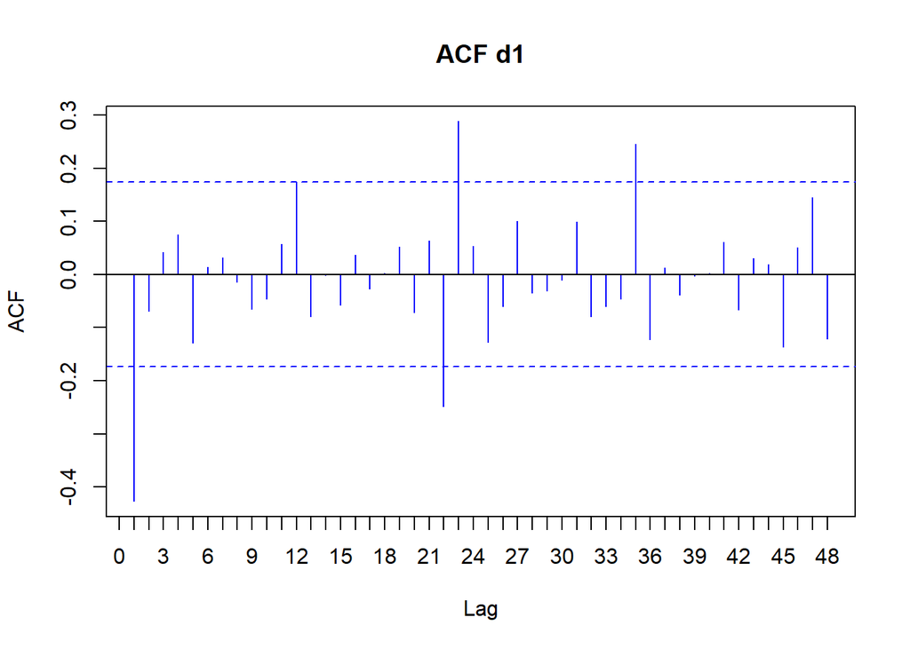

```r
acf3 <- acf(d1,lag.max=48,xaxt="n", main="ACF d1", col="blue")
axis(1, at=0:48/12, labels=0:48)
```

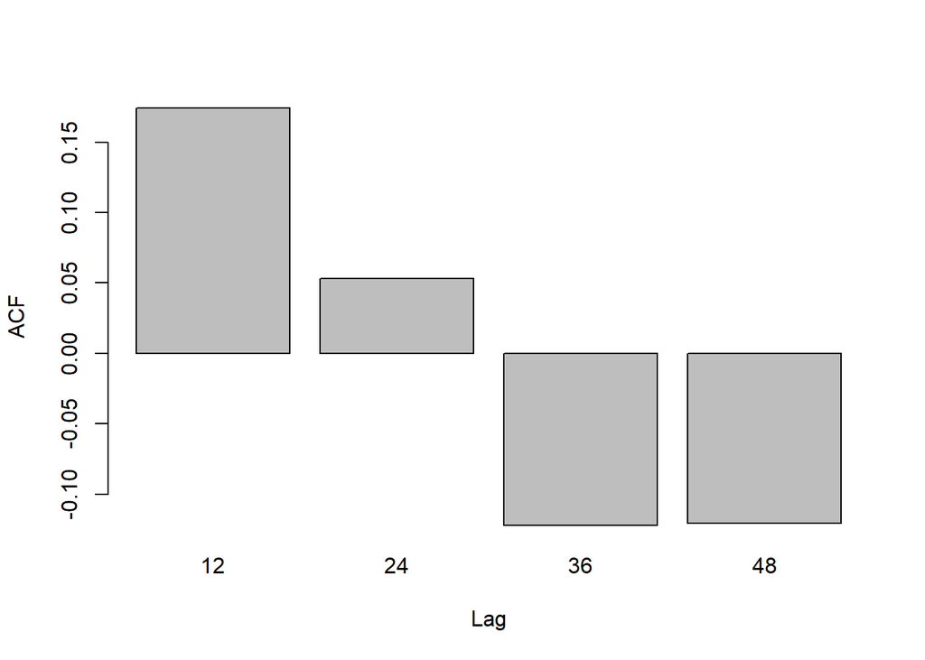

```r
acf3$lag <- acf3$lag * 12
acf3.1 <- as.data.frame(cbind(acf3$acf,acf3$lag))
acf3.2 <- acf3.1[which(acf3.1$V2%%12==0),]
barplot(height = acf3.2$V1, names.arg=acf3.2$V2, ylab="ACF",
xlab="Lag")
```

Berdasarkan plot ACF tersebut lag 1 signifikan sehingga dipilih ordo q=1 dan lag 12 adalah satu-satunya lag musiman yang signifikan sehingga order Q=1.

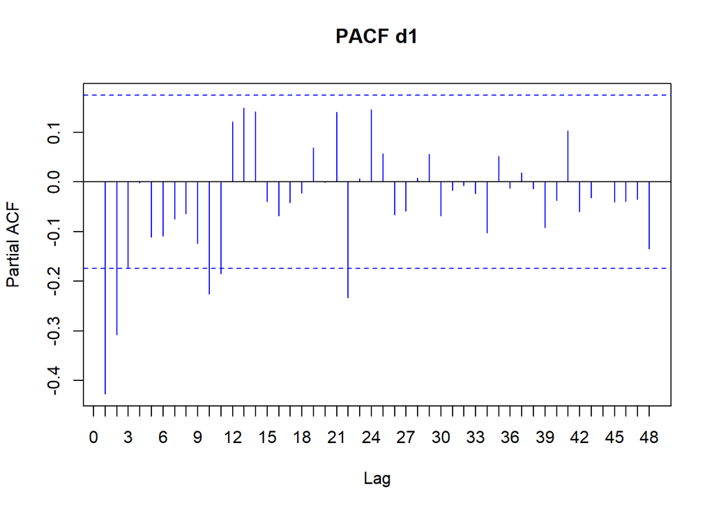

```r
pacf3 <- pacf(d1,lag.max=48,xaxt="n", main="PACF d1", col="blue")
axis(1, at=0:48/12, labels=0:48)
```

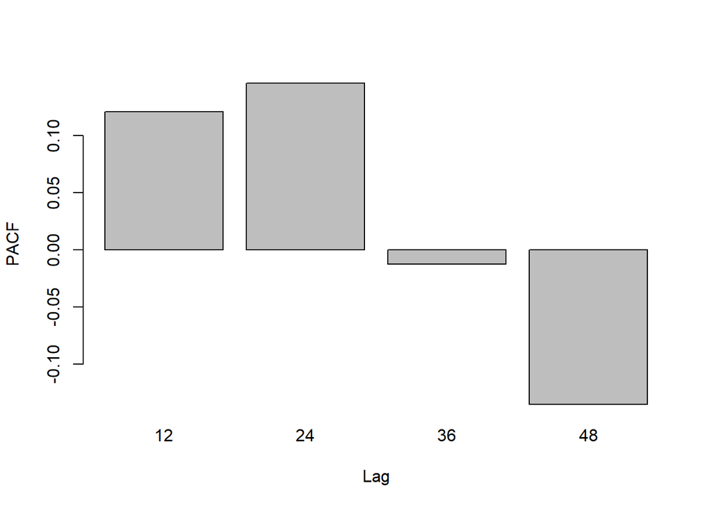

```r
pacf3$lag <- pacf3$lag * 12
pacf3.1 <- as.data.frame(cbind(pacf3$acf,pacf3$lag))
pacf3.2 <- pacf3.1[which(pacf3.1$V2%%12==0),]
barplot(height = pacf3.2$V1, names.arg=pacf3.2$V2, ylab="PACF", xlab="Lag")
```

Plot PACF tersebut menunjukkan cuts-off pada lag-2 sehingga ordo p=2, sementara pada pola musimannya tidak terlihat model AR yang terbentuk karena cenderung tails-off.

Model musiman yang dipilih untuk deret jumlah angkutan barang adalah $ARIMA(0,1,1)×(0,0,1)_{12}$, $ARIMA(2,1,0)×(0,0,1)_{12}$.

# EACF

```r
TSA::eacf(d1)
```

```
## AR/MA
##   0 1 2 3 4 5 6 7 8 9 10 11 12 13
## 0 x o o o o o o o o o o  o  o  o
## 1 x x o o o o o o o o o  x  o  o
## 2 x x x o o o o o o o o  x  o  o
## 3 o x x o o o o o o o o  o  o  o
## 4 o x x o o o o o o o o  x  o  o
## 5 x o o o o o o o o o o  o  o  o
## 6 x o o o o o o o o o o  o  o  o
## 7 x o o o o o o x o o o  o  o  o
```

Model tentatif yang diperoleh adalah $ARIMA(0,1,1)×(0,0,1)_{12}$, $ARIMA(2,1,0)×(0,0,1)_{12}$, $ARIMA(1,1,2)×(0,0,1)_{12}$, $ARIMA(2,1,3)×(0,0,1)_{12}$, $ARIMA(3,1,3)×(0,0,1)_{12}$

# Pendugaan Parameter

```r
#ARIMA(0,1,1)x(0,0,1)12
tmodel1 <- Arima(train.ts,order=c(0,1,1),seasonal=c(0,0,1))
summary(tmodel1)
```

```
## Series: train.ts
## ARIMA(0,1,1)(0,0,1)[12]
##
## Coefficients:
##          ma1    sma1
##       -0.672  0.2321
## s.e.   0.070  0.0756
##
## sigma^2 = 15904:  log likelihood = -794.15
## AIC=1594.3   AICc=1594.49   BIC=1602.83
##
## Training set error measures:
##                    ME    RMSE      MAE        MPE    MAPE      MASE        ACF1
## Training set 17.89848 124.625 86.29472 -0.3095711 13.7927 0.6200178 -0.01999532
```

```r
lmtest::coeftest(tmodel1)
```

```
##
## z test of coefficients:
##
##       Estimate Std. Error z value  Pr(>|z|)
## ma1  -0.672015   0.070002 -9.6000 < 2.2e-16 ***
## sma1  0.232104   0.075645  3.0683  0.002153 **
## ---
## Signif. codes:  0 '***' 0.001 '**' 0.01 '*' 0.05 '.' 0.1 ' ' 1
```

```r
#ARIMA(2,1,0)x(0,0,1)12
tmodel2 <- Arima(train.ts,order=c(2,1,0),seasonal=c(0,0,1))
summary(tmodel2)
```

```
## Series: train.ts
## ARIMA(2,1,0)(0,0,1)[12]
##
## Coefficients:
##           ar1      ar2    sma1
##       -0.6092  -0.3785  0.2701
## s.e.   0.0836   0.0866  0.0783
##
## sigma^2 = 16164:  log likelihood = -794.76
## AIC=1597.51   AICc=1597.84   BIC=1608.89
##
## Training set error measures:
##                    ME     RMSE      MAE      MPE     MAPE      MASE        ACF1
## Training set 11.48535 125.1346 88.58653 -1.15274 14.58215 0.6364842 -0.06658831
```

```r
lmtest::coeftest(tmodel2)
```

```
##
## z test of coefficients:
##
##       Estimate Std. Error z value  Pr(>|z|)
## ar1  -0.609234   0.083608 -7.2868 3.175e-13 ***
## ar2  -0.378526   0.086622 -4.3699 1.243e-05 ***
## sma1  0.270091   0.078329  3.4482 0.0005644 ***
## ---
## Signif. codes:  0 '***' 0.001 '**' 0.01 '*' 0.05 '.' 0.1 ' ' 1
```

```r
#ARIMA(1,1,2)x(0,0,1)12
tmodel3 <- Arima(train.ts,order=c(1,1,2),seasonal=c(0,0,1))
summary(tmodel3)
```

```
## Series: train.ts
## ARIMA(1,1,2)(0,0,1)[12]
##
## Coefficients:
##           ar1      ma1      ma2    sma1
##       -0.5260  -0.1220  -0.3910  0.2322
## s.e.   0.6861   0.6731   0.4432  0.0763
##
## sigma^2 = 16132:  log likelihood = -794.03
## AIC=1598.06   AICc=1598.56   BIC=1612.28
##
## Training set error measures:
##                    ME     RMSE      MAE       MPE     MAPE      MASE       ACF1
## Training set 18.27534 124.5074 86.50962 -0.256099 13.81761 0.6215619 -0.0435177
```

```r
lmtest::coeftest(tmodel1)
```

```
##
## z test of coefficients:
##
##       Estimate Std. Error z value  Pr(>|z|)
## ma1  -0.672015   0.070002 -9.6000 < 2.2e-16 ***
## sma1  0.232104   0.075645  3.0683  0.002153 **
## ---
## Signif. codes:  0 '***' 0.001 '**' 0.01 '*' 0.05 '.' 0.1 ' ' 1
```

```r
#ARIMA(2,1,3)x(0,0,1)12
tmodel4 <- Arima(train.ts,order=c(2,1,3),seasonal=c(0,0,1))
summary(tmodel4)
```

```
## Series: train.ts
## ARIMA(2,1,3)(0,0,1)[12]
##
## Coefficients:
##           ar1      ar2      ma1     ma2     ma3    sma1
##       -0.5751  -0.9776  -0.0685  0.5511  -0.610  0.3045
## s.e.   0.0467   0.0390   0.0936  0.0805   0.094  0.0813
##
## sigma^2 = 15541:  log likelihood = -791.04
## AIC=1596.08   AICc=1597.02   BIC=1615.98
##
## Training set error measures:
##                    ME     RMSE      MAE        MPE     MAPE      MASE
## Training set 16.28295 121.2069 84.26623 -0.4467344 13.68595 0.6054433
##                    ACF1
## Training set -0.0440072
```

```r
lmtest::coeftest(tmodel4)
```

```
##
## z test of coefficients:
##
##       Estimate Std. Error  z value  Pr(>|z|)
## ar1  -0.575124   0.046655 -12.3272 < 2.2e-16 ***
## ar2  -0.977648   0.039032 -25.0474 < 2.2e-16 ***
## ma1  -0.068516   0.093578  -0.7322 0.4640601
## ma2   0.551120   0.080544   6.8425 7.783e-12 ***
## ma3  -0.610033   0.094018  -6.4885 8.671e-11 ***
## sma1  0.304477   0.081318   3.7443 0.0001809 ***
## ---
## Signif. codes:  0 '***' 0.001 '**' 0.01 '*' 0.05 '.' 0.1 ' ' 1
```

```r
#ARIMA(3,1,3)x(0,0,1)12
tmodel5 <- Arima(train.ts,order=c(3,1,3),seasonal=c(0,0,1))
summary(tmodel5)
```

```
## Series: train.ts
## ARIMA(3,1,3)(0,0,1)[12]
##
## Coefficients:
##          ar1      ar2     ar3      ma1     ma2      ma3    sma1
##       0.0131  -0.9521  0.1070  -0.6781  0.9956  -0.6845  0.2242
## s.e.  0.1692   0.0383  0.1662   0.1382  0.0384   0.1317  0.0813
##
## sigma^2 = 14774:  log likelihood = -788.98
## AIC=1593.97   AICc=1595.19   BIC=1616.72
##
## Training set error measures:
##                    ME     RMSE      MAE        MPE     MAPE      MASE
## Training set 16.76872 117.6877 83.75208 -0.3067802 13.59908 0.6017492
##                     ACF1
## Training set -0.02774296
```

```r
lmtest::coeftest(tmodel5)
```

```
##
## z test of coefficients:
##
##       Estimate Std. Error  z value  Pr(>|z|)
## ar1   0.013144   0.169239   0.0777  0.938092
## ar2  -0.952107   0.038300 -24.8595 < 2.2e-16 ***
## ar3   0.106981   0.166241   0.6435  0.519883
## ma1  -0.678142   0.138172  -4.9080 9.203e-07 ***
## ma2   0.995605   0.038363  25.9523 < 2.2e-16 ***
## ma3  -0.684541   0.131737  -5.1963 2.033e-07 ***
## sma1  0.224239   0.081347   2.7566  0.005841 **
## ---
## Signif. codes:  0 '***' 0.001 '**' 0.01 '*' 0.05 '.' 0.1 ' ' 1
```

```r
AICKandidatModel <- c(tmodel1$aic, tmodel2$aic, tmodel3$aic,
                      tmodel4$aic, tmodel5$aic)
AICcKandidatModel <- c(tmodel1$aicc, tmodel2$aicc, tmodel3$aicc,
                       tmodel4$aicc, tmodel5$aicc)
BICKandidatModel <- c(tmodel1$bic, tmodel2$bic, tmodel3$bic,
                      tmodel4$bic, tmodel5$bic)
KandidatModelARIMA <- c("ARIMA(0,1,1)(0,0,1)12", "ARIMA(2,1,0)(0,0,1)12",
                        "ARIMA(1,1,2)(0,0,1)12", "ARIMA(2,1,3)(0,0,1)12",
                        "ARIMA(3,1,3)(0,0,1)12")
compmodelARIMA <- cbind(KandidatModelARIMA, AICKandidatModel,
                        AICcKandidatModel, BICKandidatModel)
colnames(compmodelARIMA) <- c("Kandidat Model", "Nilai AIC",
                              "Nilai AICc", "Nilai BIC")
compmodelARIMA <- as.data.frame(compmodelARIMA)
compmodelARIMA
```

```
##          Kandidat Model        Nilai AIC       Nilai AICc        Nilai BIC
## 1 ARIMA(0,1,1)(0,0,1)12 1594.29635911093 1594.49148106215 1602.82892037031
## 2 ARIMA(2,1,0)(0,0,1)12 1597.51018285996 1597.83805171242  1608.8869312058
## 3 ARIMA(1,1,2)(0,0,1)12 1598.06125482401  1598.5571225926  1612.2821902563
## 4 ARIMA(2,1,3)(0,0,1)12 1596.07554479294 1597.01672126352 1615.98485439815
## 5 ARIMA(3,1,3)(0,0,1)12 1593.96879474005  1595.1891337231 1616.72229143172
```

Model terbaik berdasarkan nilai AIC terkecil dari kandidat model yaitu ARIMA(3,1,3)×(0,0,1)12, tetapi dengan mempertimbangkan signifikansi parameter dan kesederhanaan model akan dipilih ARIMA(0,1,1)×(0,0,1)12.

## Diagnostik Model

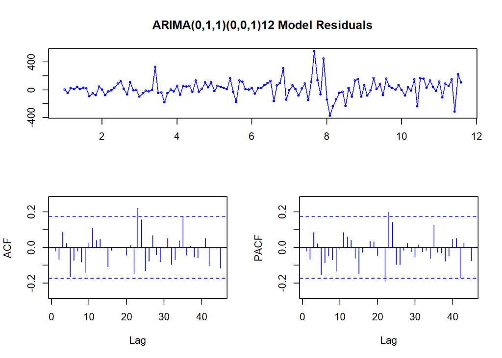

```r
tsdisplay(residuals(tmodel1), lag.max=45,
          main='ARIMA(0,1,1)(0,0,1)12 Model Residuals', col="blue")
```

```r
sisaan.model1 <- tmodel1$residuals
par(mfrow=c(2,2))
car::qqPlot(sisaan.model1)
```

```
## [1] 81 84
```

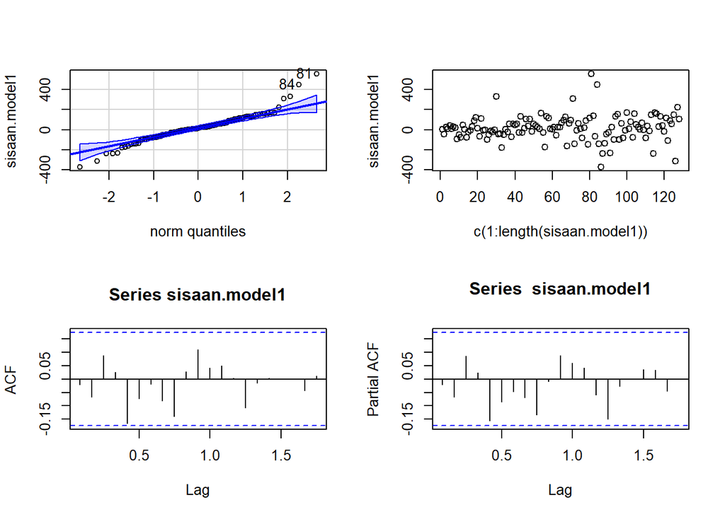

```r
plot(c(1:length(sisaan.model1)),sisaan.model1)
acf(sisaan.model1)
pacf(sisaan.model1)
```

## Uji Formal

```r
#1) Sisaan Menyebar Normal
ks.test(sisaan.model1,"pnorm")
```

```
##
##  Asymptotic one-sample Kolmogorov-Smirnov test
##
## data:  sisaan.model1
## D = 0.57031, p-value < 2.2e-16
## alternative hypothesis: two-sided
```

```r
shapiro.test(sisaan.model1)
```

```
##
##  Shapiro-Wilk normality test
##
## data:  sisaan.model1
## W = 0.93423, p-value = 9.734e-06
```

```r
nortest::ad.test(sisaan.model1)
```

```
##
##  Anderson-Darling normality test
##
## data:  sisaan.model1
## A = 1.9417, p-value = 5.618e-05
```

Berdasarkan uji KS tersebut, didapat p-value sebesar 0.000 yang lebih kecil dari taraf nyata 5% sehingga tolak H0 dan menandakan bahwa sisaan tidak menyebar normal. Hal ini berbeda dengan eksplorasi.

```r
#2) Sisaan saling bebas/tidak ada autokorelasi
Box.test(sisaan.model1, type = "Ljung")
```

```
##
##  Box-Ljung test
##
## data:  sisaan.model1
## X-squared = 0.052385, df = 1, p-value = 0.819
```

Berdasarkan uji Ljung-Box tersebut, didapat p-value sebesar 0.819 yang lebih besar dari taraf nyata 5% sehingga tak tolak H0 dan menandakan bahwa sisaan saling bebas. Hal ini sesuai dengan eksplorasi.

```r
#3) Sisaan homogen
Box.test((sisaan.model1)^2, type = "Ljung")
```

```
##
##  Box-Ljung test
##
## data:  (sisaan.model1)^2
## X-squared = 0.80237, df = 1, p-value = 0.3704
```

Berdasarkan uji Ljung-Box terhadap sisaan kuadrat tersebut, didapat p-value sebesar 0.3704 yang lebih besar dari taraf nyata 5% sehingga tak tolak H0 dan menandakan bahwa ragam sisaan homogen. Hal ini berbeda dengan eksplorasi.

```r
#4) Nilai tengah sisaan sama dengan nol
t.test(sisaan.model1, mu = 0, conf.level = 0.95)
```

```
##
##  One Sample t-test
##
## data:  sisaan.model1
## t = 1.6355, df = 127, p-value = 0.1044
## alternative hypothesis: true mean is not equal to 0
## 95 percent confidence interval:
##  -3.75779 39.55475
## sample estimates:
## mean of x
##  17.89848
```

Berdasarkan uji-ttersebut, didapat p-value sebesar 0.1044 yang lebih besar dari taraf nyata 5% sehingga tak tolak H0 dan menandakan bahwa nilai tengah sisaan sama dengan nol. Hal ini sesuai dengan eksplorasi.

## Overfitting

Pertama, overfit pada model non-musimannya (p,q)

```r
#ARIMA(1,1,1)x(0,0,1)12
tmodel1.ofp <- Arima(train.ts,order=c(1,1,1),seasonal=c(0,0,1))
summary(tmodel1.ofp)
```

```
## Series: train.ts
## ARIMA(1,1,1)(0,0,1)[12]
##
## Coefficients:
##          ar1      ma1    sma1
##       0.0133  -0.6799  0.2311
## s.e.  0.1400   0.1072  0.0764
##
## sigma^2 = 16032:  log likelihood = -794.14
## AIC=1596.29   AICc=1596.62   BIC=1607.66
##
## Training set error measures:
##                    ME     RMSE      MAE        MPE     MAPE      MASE
## Training set 18.08177 124.6228 86.32865 -0.2840863 13.78876 0.6202616
##                     ACF1
## Training set -0.02537183
```

```r
lmtest::coeftest(tmodel1.ofp)
```

```
##
## z test of coefficients:
##
##       Estimate Std. Error z value  Pr(>|z|)
## ar1   0.013345   0.140006  0.0953  0.924066
## ma1  -0.679926   0.107206 -6.3423 2.264e-10 ***
## sma1  0.231138   0.076402  3.0253  0.002484 **
## ---
## Signif. codes:  0 '***' 0.001 '**' 0.01 '*' 0.05 '.' 0.1 ' ' 1
```

```r
#ARIMA(0,1,2)x(0,0,1)12
tmodel1.ofq <- Arima(train.ts,order=c(0,1,2),seasonal=c(0,0,1))
summary(tmodel1.ofq)
```

```
## Series: train.ts
## ARIMA(0,1,2)(0,0,1)[12]
##
## Coefficients:
##           ma1     ma2    sma1
##       -0.6653  -0.011  0.2309
## s.e.   0.0941   0.104  0.0765
##
## sigma^2 = 16032:  log likelihood = -794.14
## AIC=1596.29   AICc=1596.61   BIC=1607.66
##
## Training set error measures:
##                    ME     RMSE      MAE        MPE     MAPE      MASE
## Training set 18.11911 124.6223 86.33547 -0.2788607 13.78791 0.6203106
##                     ACF1
## Training set -0.02661686
```

```r
lmtest::coeftest(tmodel1.ofq)
```

```
##
## z test of coefficients:
##
##       Estimate Std. Error z value  Pr(>|z|)
## ma1  -0.665302   0.094080 -7.0717 1.531e-12 ***
## ma2  -0.011023   0.103988 -0.1060   0.91558
## sma1  0.230935   0.076504  3.0186   0.00254 **
## ---
## Signif. codes:  0 '***' 0.001 '**' 0.01 '*' 0.05 '.' 0.1 ' ' 1
```

Pada model musiman, ordo yang dilakukan overfit adalah ordo musiman (P, Q).

```r
#ARIMA(0,1,1)x(1,0,1)12
tmodel1.ofP <- Arima(train.ts,order=c(0,1,1),seasonal=c(1,0,1))
summary(tmodel1.ofP)
```

```
## Series: train.ts
## ARIMA(0,1,1)(1,0,1)[12]
##
## Coefficients:
##           ma1    sar1     sma1
##       -0.6807  0.4891  -0.1979
## s.e.   0.0685  0.1920   0.2047
##
## sigma^2 = 15507:  log likelihood = -792.37
## AIC=1592.73   AICc=1593.06   BIC=1604.11
##
## Training set error measures:
##                    ME     RMSE      MAE        MPE     MAPE      MASE
## Training set 15.81086 122.5647 83.62539 -0.3908529 13.44341 0.6008389
##                     ACF1
## Training set -0.03657552
```

```r
lmtest::coeftest(tmodel1.ofP)
```

```
##
## z test of coefficients:
##
##       Estimate Std. Error z value Pr(>|z|)
## ma1  -0.680677   0.068478 -9.9400  < 2e-16 ***
## sar1  0.489138   0.192006  2.5475  0.01085 *
## sma1 -0.197945   0.204665 -0.9672  0.33346
## ---
## Signif. codes:  0 '***' 0.001 '**' 0.01 '*' 0.05 '.' 0.1 ' ' 1
```

```r
#ARIMA(0,1,1)x(0,0,2)12
tmodel1.ofQ <- Arima(train.ts,order=c(0,1,1),seasonal=c(0,0,2))
summary(tmodel1.ofQ)
```

```
## Series: train.ts
## ARIMA(0,1,1)(0,0,2)[12]
##
## Coefficients:
##           ma1    sma1    sma2
##       -0.6701  0.2660  0.2148
## s.e.   0.0696  0.0857  0.0964
##
## sigma^2 = 15299:  log likelihood = -791.7
## AIC=1591.41   AICc=1591.74   BIC=1602.78
##
## Training set error measures:
##                    ME    RMSE      MAE        MPE     MAPE      MASE       ACF1
## Training set 15.65045 121.743 82.71914 -0.3997241 13.27232 0.5943277 -0.0325058
```

```r
lmtest::coeftest(tmodel1.ofQ)
```

```
##
## z test of coefficients:
##
##       Estimate Std. Error z value  Pr(>|z|)
## ma1  -0.670097   0.069595 -9.6286 < 2.2e-16 ***
## sma1  0.266002   0.085690  3.1042  0.001908 **
## sma2  0.214806   0.096382  2.2287  0.025835 *
## ---
## Signif. codes:  0 '***' 0.001 '**' 0.01 '*' 0.05 '.' 0.1 ' ' 1
```

Model overfitting dengan menaikkan 1 ordo Q menghasilkan nilai AIC yang lebih kecil dari model yang dipilih sebelumnya serta semua parameter signifikan. Oleh karena itu, model $ARIMA(0,1,1)×(0,0,2)_{12}$ hasil overfitting akan digunakan.

## Peramalan

```r
ramalan_sarima = forecast::forecast(tmodel1.ofQ, 28)
ramalan_sarima
```

```
##        Point Forecast     Lo 80    Hi 80     Lo 95    Hi 95
## Sep 11       1237.453 1078.9368 1395.970  995.0233 1479.883
## Oct 11       1261.949 1095.0289 1428.869 1006.6668 1517.231
## Nov 11       1250.715 1075.7948 1425.635  983.1977 1518.232
## Dec 11       1242.488 1059.9184 1425.058  963.2717 1521.705
## Jan 12       1273.231 1083.3189 1463.143  982.7855 1563.676
## Feb 12       1223.019 1026.0386 1420.000  921.7634 1524.275
## Mar 12       1281.676 1077.8723 1485.481  969.9849 1593.368
## Apr 12       1259.254 1048.8475 1469.661  937.4650 1581.043
## May 12       1327.504 1110.6959 1544.312  995.9247 1659.083
## Jun 12       1144.712  921.6864 1367.738  803.6237 1485.800
## Jul 12       1338.366 1109.2915 1567.441  988.0267 1688.706
## Aug 12       1322.783 1087.8147 1557.751  963.4301 1682.136
## Sep 12       1304.027 1050.7826 1557.272  916.7229 1691.332
## Oct 12       1317.187 1055.4317 1578.943  916.8665 1717.508
## Nov 12       1303.458 1033.4592 1573.457  890.5306 1716.385
## Dec 12       1306.047 1028.0493 1584.044  880.8864 1731.207
## Jan 13       1322.718 1036.9458 1608.490  885.6673 1759.769
## Feb 13       1285.787  992.4464 1579.128  837.1611 1734.413
## Mar 13       1317.648 1016.9286 1618.367  857.7374 1777.558
## Apr 13       1309.284 1001.3630 1617.205  838.3595 1780.208
## May 13       1336.926 1021.9684 1651.884  855.2398 1818.613
## Jun 13       1247.334  925.4927 1569.175  755.1204 1739.547
## Jul 13       1339.794 1011.2137 1668.374  837.2740 1842.314
## Aug 13       1325.295  990.1118 1660.479  812.6763 1837.914
## Sep 13       1314.566  964.7100 1664.422  779.5074 1849.625
## Oct 13       1314.566  956.2421 1672.890  766.5568 1862.576
## Nov 13       1314.566  947.9698 1681.163  753.9054 1875.227
## Dec 13       1314.566  939.8800 1689.252  741.5331 1887.599
```

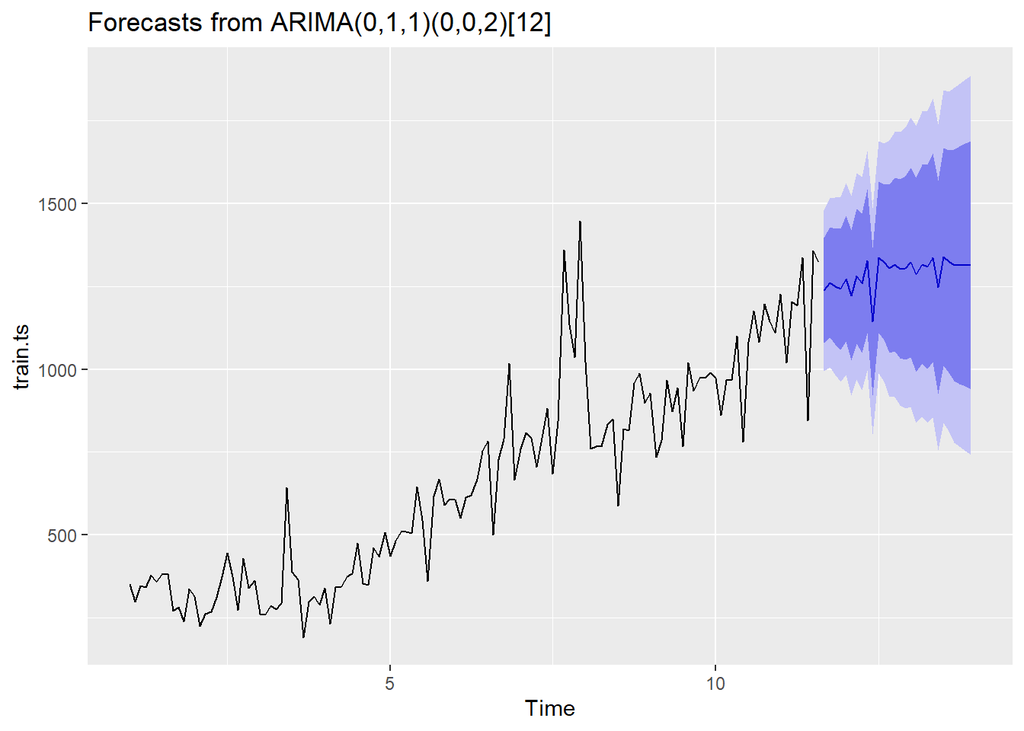

```r
autoplot(ramalan_sarima, col="blue")
```

```r
accuracy(ramalan_sarima,test.ts)
```

```
##                      ME    RMSE       MAE         MPE     MAPE      MASE
## Training set   15.65045 121.743  82.71914  -0.3997241 13.27232 0.5943277
## Test set     -209.67574 274.757 231.98966 -22.5919742 24.25285 1.6668195
##                    ACF1 Theil's U
## Training set -0.0325058        NA
## Test set      0.7442137   2.12305
```